# Introduction to R

TU Dresden

Author

Sarah Listabarth and Ronja Huhn

[figure not shown]

# Today’s Agenda

- Get familiar with R and R-Studio
- Get familiar with Quarto
- First Data-Wrangling Excercises

# Data science workflow

# Why Focus on Data Visualization?

- its a key part of data analysis
- helps to understand the data
- helps to communicate the data

# Why R?

- beginner-friendly programming language
- easy data-handling ✨
- programmming language specifically for statistics
- awesome for creating graphs 📈

# Examples

[figure not shown]

# Examples

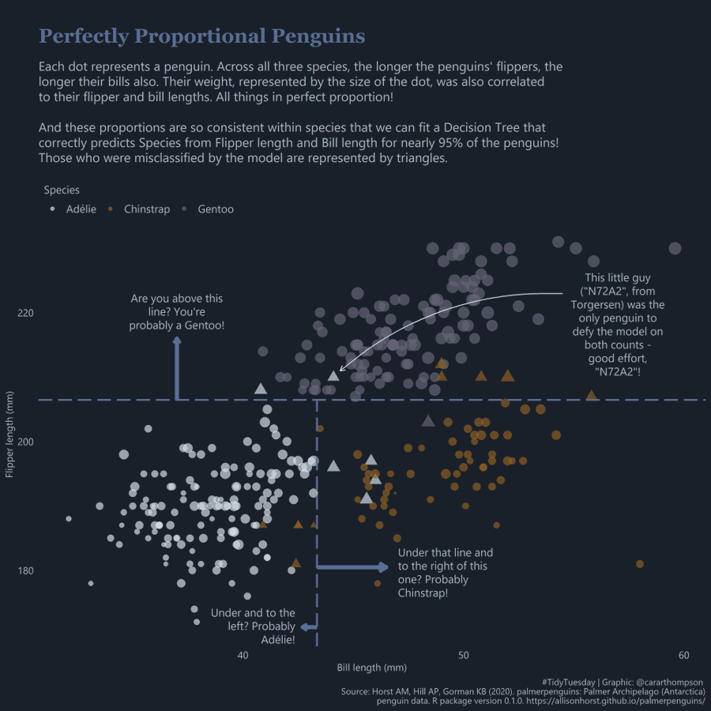

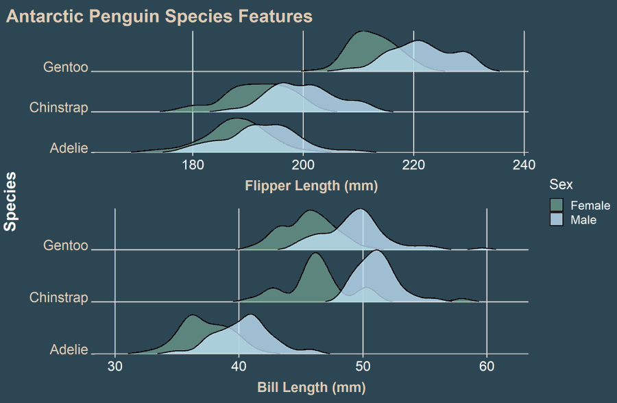

# So what can you do with `R`?

# Basics in R

- **Values**: `1, "Dresden", "2024-12-10"`
- **Objects**: `x <- c(22/7, 0.99, 3)`
- **Functions**: `round(x, digits = 3`

## Excursion: Classes

- numeric (`1.34`, `-10.6`)
- integer (`1`, `-99`)
- character (`"hello"`, `"world"`)
- `NA`s: “not assigned”
- factors

## Pop quiz – NAs

# Let’s get started! 🚀

- Open *RStudio*
- Create an R-project (`.rproj`)
- Open a `.R` script
- Save this script
- Let’s check out the different panes 🔎

## In the console

Let’s use this as a calculator.

Let’s learn how to use a function. For this, we need to add *arguments* to the function call.

```r
?head
?names
?plot
```

## In the `R` script…

Let’s calculate again. To execute a line of code, use `Ctrl` + `Enter`.

## Comments

We’re still in the R script. What if we want to explain to others (or our future self) what we intended with this code?

## Assigning (`<-`)

What if we want to create a new object? Easy:

## Datasets

Let’s have a look at a data set: `mtcars`. What is it about?

## Packages

What if we want more functions? We install packages, which contain functions. We install them once (in the console).

We can then load them (once per script).

# Your turn!

Have a look at the dataset `palmerpenguins`. What is it about?

# Let’s start this course